# IPBMA_4: Visibility of a nodule inside a noisy image

Author: Pablo G Tahoces

```python
import numpy as np
from matplotlib import pyplot
```

```python
%run ..\\..\\auxFiles\\auxFnc.py
%run ..\\..\\auxFiles\\phantomsFnc.py
%run ..\\..\\auxFiles\\IOFnc.py
```

Incident X-ray beam and detector cell specifications

```python
# N0 -> Number of incident photons/mm2, comming from an x-ray source.
# n -> Number of points of the quantum image
# pointSize -> Size of “each point” in the quantum image in mm

N0= 4000000
n= 100*100   # Suppose a square shape detector
pointSize= 0.1
```

Creating the image, based on uniform distribution of incident photons

```python
imgData= createQuantumImage(N0, n, pointSize)
```

```
40000.0 100 100
```

```python
N1= np.mean(imgData)
print(N1)
```

```
40000.0
```

```python
# insertNoduleQImage() -> Insert a nodule in the center of an homogeneous quantum image.
# noduleSize -> Ratio between the size of the nodule and the size of a point in the quantum image.
# noduleContrast -> Nodule contrast in %

noduleSize= 10
noduleContrast= 1 # Means 1%
imgNodule= insertNoduleQImage(imgData, noduleSize, noduleContrast)
```

Show images

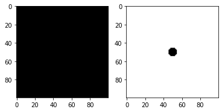

```python
pyplot.subplot(121)
pyplot.imshow(imgData, cmap="gray")

pyplot.subplot(122)
pyplot.imshow(imgNodule, cmap="gray")
pyplot.show()
```

Plot of a line that crosses the image with the nodule at the center

```
40000.0 40400.0 39600.0
40000.0 40400.0 39600.0
```

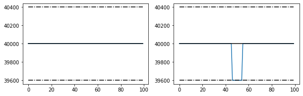

```python
pyplot.figure(figsize=(10, 3))

pyplot.subplot(121)
plotMiddleLine(imgData, N1)

pyplot.subplot(122)
plotMiddleLine(imgNodule, N1)
```

Creating the noise image, based on the Poisson distribution

```python
imgDataP= detectorNoiseP_1_1(imgData)
```

```
N Cells:  100 100
```

Creating the noise image, based on the Normal distribution

```python
imgDataN=  detectorNoiseN_1_1(imgData)
```

```
N Cells:  100 100
```

```python
print(f'{np.max(imgDataP):.1f}, {np.max(imgDataN):.1f}')
print(f'{np.min(imgDataP):.1f}, {np.min(imgDataN):.1f}')
```

```
40699.0, 40720.6
39188.0, 39235.1
```

Show the noise images

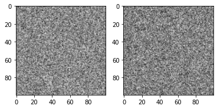

```python
pyplot.subplot(121)
pyplot.imshow(imgDataP, cmap="gray")

pyplot.subplot(122)
pyplot.imshow(imgDataN, cmap="gray")
pyplot.show()
```

Plot of a line that crosses the image of the noise images at the center

```
40000.0 40400.0 39600.0
40000.0 40400.0 39600.0
```

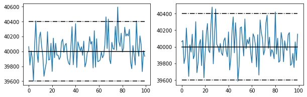

```python
# The interval limits at 2*sigma where included in the plot

pyplot.figure(figsize=(10, 3))

pyplot.subplot(121)
plotMiddleLine(imgDataP, N1)

pyplot.subplot(122)
plotMiddleLine(imgDataN, N1)
```

Plot of the distribution of the detector cells in terms of the number of photons captured

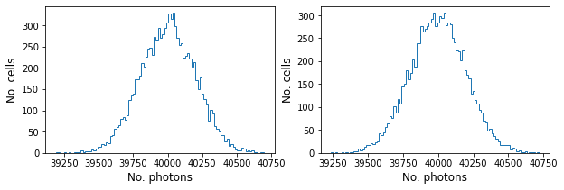

```python
# We use a number of bins= 100, to build the histograms

pyplot.figure(figsize=(10, 3))

pyplot.subplot(121)
plotCellDistribution(imgDataP, 100)

pyplot.subplot(122)
plotCellDistribution(imgDataN, 100)
```

Implementation of a noise image with a nodule superimposed in the center.

```python
# Case 1

noduleSize= 10
noduleContrast= 0.25
imgNodule_1= insertNoduleQImage(imgData, noduleSize, noduleContrast)
imgNodule_1_P= detectorNoiseP_1_1(imgNodule_1)
```

```
N Cells:  100 100
```

Showing the noise image and the nodule image for comparison

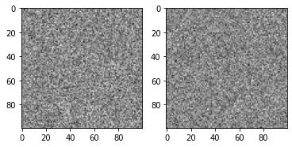

```python
pyplot.subplot(121)
pyplot.imshow(imgDataP, cmap="gray")

pyplot.subplot(122)
pyplot.imshow(imgNodule_1_P, cmap="gray")
pyplot.show()
```

Plot a line across the image through its center

```
40000.0 40400.0 39600.0
40000.0 40400.0 39600.0
```

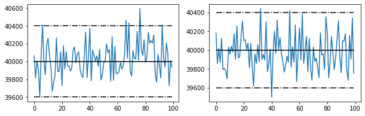

```python
pyplot.figure(figsize=(10, 3))

pyplot.subplot(121)
plotMiddleLine(imgDataP, N1)

pyplot.subplot(122)
plotMiddleLine(imgNodule_1_P, N1)
```

```python
# Case 2

noduleSize= 10
noduleContrast= 1

imgNodule_2= insertNoduleQImage(imgData, noduleSize, noduleContrast)
imgNodule_2_P= detectorNoiseP_1_1(imgNodule_2)
```

```
N Cells:  100 100
```

Showing the noise image and the nodule image for comparison

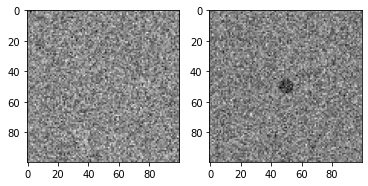

```python
pyplot.subplot(121)
pyplot.imshow(imgDataP, cmap="gray")

pyplot.subplot(122)
pyplot.imshow(imgNodule_2_P, cmap="gray")
pyplot.show()
```

Plot a line across the image through its center

```
40000.0 40400.0 39600.0
40000.0 40400.0 39600.0
```

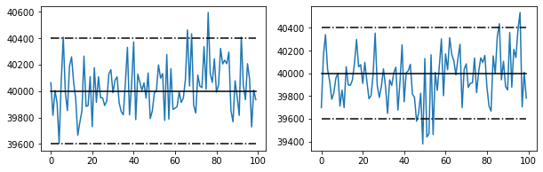

```python
pyplot.figure(figsize=(10, 3))

pyplot.subplot(121)
plotMiddleLine(imgDataP, N1)

pyplot.subplot(122)
plotMiddleLine(imgNodule_2_P, N1)
```

```python
# Case 3

noduleSize= 3
noduleContrast= 1

imgNodule_3= insertNoduleQImage(imgData, noduleSize, noduleContrast)
imgNodule_3_P= detectorNoiseP_1_1(imgNodule_3)
```

```
N Cells:  100 100
```

Showing the noise image and the nodule image for comparison

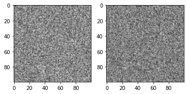

```python
pyplot.subplot(121)
pyplot.imshow(imgDataP, cmap="gray")

pyplot.subplot(122)
pyplot.imshow(imgNodule_3_P, cmap="gray")
pyplot.show()
```

Plot of a line across the image through its center

```
40000.0 40400.0 39600.0
40000.0 40400.0 39600.0
```

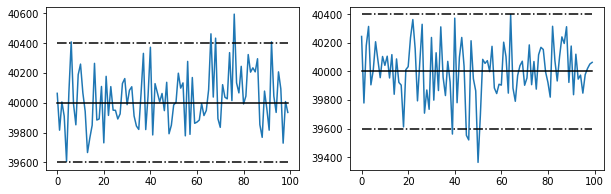

```python
pyplot.figure(figsize=(10, 3))

pyplot.subplot(121)
plotMiddleLine(imgDataP, N1)

pyplot.subplot(122)
plotMiddleLine(imgNodule_3_P, N1)
```